# Double Black restaurant Hong Kong - Google Search

# Search Results

About 69 results (0.36s)

AI Overview

**Key Details**

**Recommendations**

- **Best for:** A quiet brunch, coffee break, or taking a pet.
- **Tip:** It can get crowded on weekends.

Would you like to know more about:

- Their **full menu** and prices?
- **Alternative nearby cafés** if this one is full?
- How to **get there** from the escalators?
- Double Black (@doubleblackhk) - Instagram

  ▪️Cafè ▪️Cocktails ▪️Restaurant ▫️Mon to Fri : 8:30am-5:30pm ▫️Sat, Sun & Public Holidays: 9am-6pm #DoubleBlackHK ... Upgrade your...

[figure not shown]

  Instagram·doubleblackhk
- Double Black (Mid-Levels) - Hong Kong - OpenRice

[figure not shown]

  OpenRice
- 黑色系型格半山Cafe丨Double Black

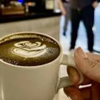

  www.timeout.com.hk

Show all

AI can make mistakes, so double-check responses

[figure not shown]

[figure not shown]

[figure not shown]

## Web results

### Double Black (Mid-Levels) - Hong Kong

OpenRice

https://www.openrice.com › hongkong › r-double-black-...

OpenRice

https://www.openrice.com › hongkong › r-double-black-...

Double Black's Address, Telephone Number, Ratings, Reviews, Photos and Menu, located at *Shop A, G/F, Kin Hing House, 26 Mosque Street Mid-Levels*.

### Double Black (@doubleblackhk)

Instagram · doubleblackhk

4.2K+ followers

Instagram · doubleblackhk

4.2K+ followers

▪️Cafè ▪️Cocktails ▪️*Restaurant* ▫️Mon to Fri : 8:30am-5:30pm ▫️Sat, Sun & Public Holidays: 9am-6pm #DoubleBlackHK ... Upgrade your winter ritual at *Double Black*![Read more](https://www.instagram.com/doubleblackhk/#:~:text=%E2%96%AA%EF%B8%8FCaf%C3%A8%20%E2%96%AA%EF%B8%8FCocktails%20%E2%96%AA%EF%B8%8FRestaurant,%23DoubleBlackHK)

### Double Black – 香港半山宏基國際賓館的西式All Day ...

OpenRice

https://www.openrice.com › r-doub...

OpenRice

https://www.openrice.com › r-doub...

· Translate this page

*Double Black* 的餐廳地址、電話、食評、相片及餐牌，餐廳位於半山摩羅廟街26號建興樓地下A號舖。主要菜式包括Beef Cheek Tomato Spaghetti, Dirty, Grilled Prawns ...

4.5(114) · Price range: $50以下

### Double Black - Hong Kong Restaurants - Tripadvisor

Tripadvisor

https://en.tripadvisor.com.hk › Restaurant_Review-g29...

Tripadvisor

https://en.tripadvisor.com.hk › Restaurant_Review-g29...

4.0(1)

### DOUBLE BLACK hong kong | architectural and interior ...

atelier c+

https://www.ateliercplus.hk › portfolio › hospitality-|-f&b

atelier c+

https://www.ateliercplus.hk › portfolio › hospitality-|-f&b

*DOUBLE BLACK* aims to capture the arts of *double black* through a menu of premium coffees and *food*, complemented by a list of selected cocktails and apres ski ...[Read more](https://www.ateliercplus.hk/portfolio/hospitality-%7C-f%26b/double-black-hong-kong#:~:text=DOUBLE%20BLACK%20aims%20to%20capture,and%20apres%20ski%20favorite%20beverages.)